# PML - Course Project

Simon C

6 April 2017

# Predicting Personal Activity

In this assignment we will predict the classification of 5 different activities recorded by 6 participants in a study.

## Background

Using devices such as Jawbone Up, Nike FuelBand, and Fitbit it is now possible to collect a large amount of data about personal activity relatively inexpensively. These type of devices are part of the quantified self movement – a group of enthusiasts who take measurements about themselves regularly to improve their health, to find patterns in their behavior, or because they are tech geeks. One thing that people regularly do is qu antify how much of a particular activity they do, but they rarely quantify how well they do it. In this project, your goal will be to use data from accelerometers on the belt, forearm, arm, and dumbell of 6 participants. They were asked to perform barbell lifts correctly and incorrectly in 5 different ways. More information is available from the website here: http://groupware.les.inf.puc-rio.br/har (see the section on the Weight Lifting Exercise Dataset).

## Data

The training data for this project are available [here](https://d396qusza40orc.cloudfront.net/predmachlearn/pml-training.csv)

The test data are available [here](https://d396qusza40orc.cloudfront.net/predmachlearn/pml-testing.csv)

```r
#set up libraries
library(caret)
library(ggplot2)
library(rpart)
library(randomForest)
```

We will first load the data.

```r
#load data
trainingdata <- read.csv('./data/pml-training.csv')
problem <- read.csv('./data/pml-testing.csv')
```

The variables missing from the test data have missing values in the training set and so we will remove them. The class response in the test set will need to be predicted. We will split the training data into training and validation sets.

```r
#remove X and username
trainingdata <- subset(trainingdata, select=!(names(trainingdata) %in% c('X','user_name','raw_timestamp_part_1','raw_timestamp_part_2','cvtd_timestamp','new_window','num_window')))

problem <- subset(problem, select=!(names(problem) %in% c('X','user_name','raw_timestamp_part_1','raw_timestamp_part_2','cvtd_timestamp','new_window','num_window')))

a <- sapply(problem,function(x){ sum(is.na(x))} )
problem <- subset(problem, select=!(names(problem) %in% names(a[a==20])))

trainingdata <- subset(trainingdata, select=(names(trainingdata) %in% c(names(problem),'classe')))


#split trainingdata into train and test
set.seed(123321)
intrain <- createDataPartition(trainingdata$classe, p=0.7, list=FALSE)

train <- trainingdata[intrain,]
test <- trainingdata[-intrain,]
```

## Prediction

We will first fit a single tree to the data to understand the based accuracy.

```r
modelRPART <- rpart(classe ~ ., data = train, method="class")
confusionMatrix(train$classe,predict(modelRPART, newdata=train, type="class"))
```

```
## Confusion Matrix and Statistics
##
##           Reference
## Prediction    A    B    C    D    E
##          A 3528  105  109   94   70
##          B  435 1595  298  209  121
##          C  134  202 1832  166   62
##          D  244  197  331 1257  223
##          E   74  213  298  117 1823
##
## Overall Statistics
##
##                Accuracy : 0.7305
##                  95% CI : (0.723, 0.7379)
##     No Information Rate : 0.3214
##     P-Value [Acc > NIR] : < 2.2e-16
##
##                   Kappa : 0.6575
##  Mcnemar's Test P-Value : < 2.2e-16
##
## Statistics by Class:
##
##                      Class: A Class: B Class: C Class: D Class: E
## Sensitivity            0.7991   0.6899   0.6388   0.6820   0.7930
## Specificity            0.9595   0.9070   0.9481   0.9163   0.9386
## Pos Pred Value         0.9032   0.6001   0.7646   0.5582   0.7220
## Neg Pred Value         0.9098   0.9353   0.9087   0.9490   0.9575
## Prevalence             0.3214   0.1683   0.2088   0.1342   0.1674
## Detection Rate         0.2568   0.1161   0.1334   0.0915   0.1327
## Detection Prevalence   0.2843   0.1935   0.1744   0.1639   0.1838
## Balanced Accuracy      0.8793   0.7984   0.7934   0.7992   0.8658
```

The single tree was only 73% accurate. Let’s try with cross-validation.

```r
tc <- trainControl("cv", 10)
rpart.grid <- expand.grid(.cp = 0.01)
train.rpart <- train(classe ~ . , data=train, method = "rpart", trControl=tc,tuneGrid=rpart.grid)
train.rpart
```

```
## CART
##
## 13737 samples
##    52 predictors
##     5 classes: 'A', 'B', 'C', 'D', 'E'
##
## No pre-processing
## Resampling: Cross-Validated (10 fold)
## Summary of sample sizes: 12364, 12363, 12363, 12364, 12363, 12363, ...
## Resampling results:
##
##   Accuracy   Kappa
##   0.7323288  0.6599946
##
## Tuning parameter 'cp' was held constant at a value of 0.01
##
```

We will now fit a Random Forest to the training data which will not need additional cross-validation. Limiting growth to 20 trees creates a model that is 99.99% accurate on the training set.

```r
#Fit RF

modelRF <- randomForest(classe ~ ., data=train, ntree=20)

confusionMatrix(train$classe,predict(modelRF, newdata=train))
```

```
## Confusion Matrix and Statistics
##
##           Reference
## Prediction    A    B    C    D    E
##          A 3906    0    0    0    0
##          B    0 2658    0    0    0
##          C    0    0 2396    0    0
##          D    0    0    0 2252    0
##          E    0    0    0    0 2525
##
## Overall Statistics
##
##                Accuracy : 1
##                  95% CI : (0.9997, 1)
##     No Information Rate : 0.2843
##     P-Value [Acc > NIR] : < 2.2e-16
##
##                   Kappa : 1
##  Mcnemar's Test P-Value : NA
##
## Statistics by Class:
##
##                      Class: A Class: B Class: C Class: D Class: E
## Sensitivity            1.0000   1.0000   1.0000   1.0000   1.0000
## Specificity            1.0000   1.0000   1.0000   1.0000   1.0000
## Pos Pred Value         1.0000   1.0000   1.0000   1.0000   1.0000
## Neg Pred Value         1.0000   1.0000   1.0000   1.0000   1.0000
## Prevalence             0.2843   0.1935   0.1744   0.1639   0.1838
## Detection Rate         0.2843   0.1935   0.1744   0.1639   0.1838
## Detection Prevalence   0.2843   0.1935   0.1744   0.1639   0.1838
## Balanced Accuracy      1.0000   1.0000   1.0000   1.0000   1.0000
```

The model also is 99% accurate on the validation set.

```r
confusionMatrix(test$classe,predict(modelRF, newdata=test))
```

```
## Confusion Matrix and Statistics
##
##           Reference
## Prediction    A    B    C    D    E
##          A 1671    1    0    2    0
##          B    8 1127    4    0    0
##          C    0   13 1011    2    0
##          D    0    0   21  943    0
##          E    0    2    2    2 1076
##
## Overall Statistics
##
##                Accuracy : 0.9903
##                  95% CI : (0.9875, 0.9927)
##     No Information Rate : 0.2853
##     P-Value [Acc > NIR] : < 2.2e-16
##
##                   Kappa : 0.9877
##  Mcnemar's Test P-Value : NA
##
## Statistics by Class:
##
##                      Class: A Class: B Class: C Class: D Class: E
## Sensitivity            0.9952   0.9860   0.9740   0.9937   1.0000
## Specificity            0.9993   0.9975   0.9969   0.9957   0.9988
## Pos Pred Value         0.9982   0.9895   0.9854   0.9782   0.9945
## Neg Pred Value         0.9981   0.9966   0.9944   0.9988   1.0000
## Prevalence             0.2853   0.1942   0.1764   0.1613   0.1828
## Detection Rate         0.2839   0.1915   0.1718   0.1602   0.1828
## Detection Prevalence   0.2845   0.1935   0.1743   0.1638   0.1839
## Balanced Accuracy      0.9973   0.9917   0.9854   0.9947   0.9994
```

## Importance

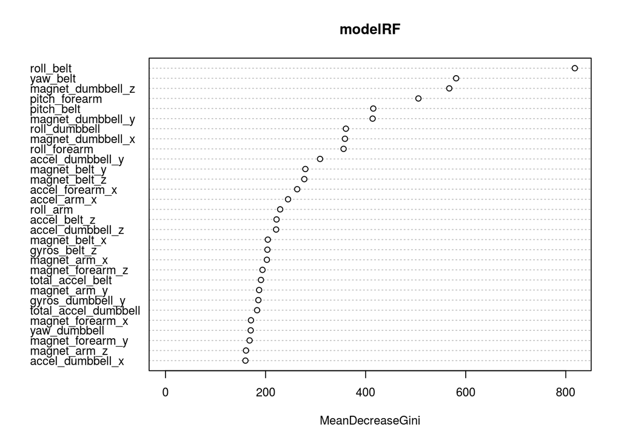

```r
varImpPlot(modelRF, type=2, col=1, cex=0.8)
```

## Prediction

Finally we will predict the classes of the 20 test observations.

```r
predict(modelRF, newdata = problem)
```

```
##  1  2  3  4  5  6  7  8  9 10 11 12 13 14 15 16 17 18 19 20
##  B  A  B  A  A  E  D  B  A  A  B  C  B  A  E  E  A  B  B  B
## Levels: A B C D E
```